# Stylized facts

2021-06-28

One useful thing for me would be if you could put together some stylized facts on the characteristics of tourism-dependent economies. To define them you can try using a 5 percent of GDP threshold for the travel trade balance during 2015-19, and then maybe 3 percent. The stylized facts would be average, median, and overall range for GDP per capita, population, current account balance (also 2015-19) and net IIP (all variables in the database). And you can contrast those figures with the figures for the remaining countries. Thank you and happy of course to explain in more detail.

```r
librarian::shelf(tidyverse)
tourism <- readRDS('data/tourism.rds')

# Tourisim dependent is define as crossing a five percent threshold for travel balance during 2015-2019
tourism_dependent <-
  tourism %>%
  filter(travel_balance_2015_2019 > 5)

tourism_dependent_summary <-
  tourism_dependent %>%

  # Stylized facts are average, median, and range for
  # GDP per capita, population, current acount balance from 2015 to 2019, and
  # net international investment position.
  summarise(across(
    # Columns to summarise
    .cols = c(
      gdp_per_capita_2019,
      population_2019,
      current_account_2015_2019,
      iip_2019
    ),
    # Functions to use.
    # Note: To use multiple functions inside across you can put them in a list!
    .fns = list(
      min = min,
      mean = mean,
      median = median,
      max = max
    ),
    # Additional arguments to pass on to the list of functions
    na.rm = TRUE,
    .names = '{.col}_{.fn}'
  ))
```

Now that we’ve calculated the appropriate summary statistics we can do some data wrangling to tidy our data. Our goal is to structure the data so that each row is an observation and each column is a statistics for that observation. We can accomplish this by first pivoting longer on the function names using `tidyr::pivot_longer()` and `tidyr::pivot_wider()`.

```r
tourism_dependent_summary_long <-
  tourism_dependent_summary %>%
      pivot_longer(
      # Pivot on all numeric values
      cols = where(is.numeric),
      # What we want our new column names to be
      names_to = c('variable', 'statistic'),
      # Alternatively, we can use (.*)_(.*) which is more general.
      # I'm just being explicit here to show what the .* placeholder is doing!
      names_pattern = '(.*)_(min|mean|median|max)',
      values_to = 'value'
    )

tourism_dependent_summary_wide <-
  tourism_dependent_summary_long %>%
  # Take the names of the values in the statistic column and turn them into columns.
  # I.e, we want columns for min, mean, median, max, and range
  pivot_wider(names_from = statistic, values_from = value) %>%
  mutate(range = max - min)

# `%not_in%` <- Negate(`%in%`)
#


# tourism_dependent_summary_wide %>%
#   mutate(range = max - min) %>%
#   # Column based selection:
#   #   select(country, population_2019,gdpd_2019) %>%
#   # Row based selection:
#      filter(variable %in% c( 'gdp_per_capita_2019')) %>%
#   ggplot(aes(x = fct_reorder(country, (gdpd_2019)),
#              y  = gdpd_2019,
#              fill = country)) +
#   geom_col()  +
#   coord_flip()
```

## User defined functions

We want to do the exact same thing but for slightly different specifications. In particular, we want to to see how these numbers change depending on the threshold we choose for tourism dependent and compared to non tourism dependent economies. Therefore, it makes sense to put our cleaning recipe into a user defined function. Think of the function as a black box that saves us from being repetitive.

```r
our_summary <- function(data){
  data %>%
    mutate(gdp_per_capita_2019 = gdpd_2019 / population_2019) %>%
  # Stylized facts are average, median, and range for
  # GDP per capita, population, current acount balance from 2015 to 2019, and
  # net international investment position.
  summarise(across(
    # Columns to summarise
    .cols = c(
      gdp_per_capita_2019,
      population_2019,
      current_account_2015_2019,
      iip_2019
    ),
    # Functions to use.
    # Note: To use multiple functions inside across you can put them in a list!
    .fns = list(
      min = min,
      mean = mean,
      median = median,
      max = max
    ),
    # Additional arguments to pass on to the list of functions
    na.rm = TRUE,
    .names = '{.col}_{.fn}'
  )) %>%
       pivot_longer(
      # Pivot on all numeric values
      where(is.numeric),
      # What we want our new column names to be
      names_to = c('variable', 'statistic'),
      # Alternatively, we can use (.*)_(.*) which is more general.
      # I'm just being explicit here to show what the .* placeholder is doing!
      names_pattern = '(.*)_(min|mean|median|max)',
      values_to = 'values'
    ) %>%
  # Take the names of the values in the statistic column and turn them into columns.
  # I.e, we want columns for min, mean, median, max, and range
  pivot_wider(names_from = statistic, values_from = values) %>%
  mutate(range = max - min)
}

 tourism %>%
  filter(travel_balance_2015_2019 > 3) %>%
   our_summary()
```

```
## # A tibble: 4 x 6
##   variable                       min   mean median   max range
##   <chr>                        <dbl>  <dbl>  <dbl> <dbl> <dbl>
## 1 gdp_per_capita_2019         0.540  15.0    8.90  81.1  80.6
## 2 population_2019             0.0170  6.84   0.885 69.6  69.6
## 3 current_account_2015_2019 -21.5    -4.23  -4.16  29.5  51.0
## 4 iip_2019                   -1.70   -0.669 -0.694  1.71  3.41
```

```r
  tourism %>%
  filter(travel_balance_2015_2019 <= 3) %>%
   our_summary()
```

```
## # A tibble: 4 x 6
##   variable                       min    mean median    max  range
##   <chr>                        <dbl>   <dbl>  <dbl>  <dbl>  <dbl>
## 1 gdp_per_capita_2019         0.257  14.6     4.53   116.   116.
## 2 population_2019             0.0110 52.1    11.8   1400.  1400.
## 3 current_account_2015_2019 -37.1    -2.20   -2.11    32.7   69.9
## 4 iip_2019                   -3.63    0.0953 -0.291   11.6   15.2
```

```r
 tourism %>%
  filter(travel_balance_2015_2019 > 5) %>%
   our_summary()
```

```
## # A tibble: 4 x 6
##   variable                       min   mean median   max range
##   <chr>                        <dbl>  <dbl>  <dbl> <dbl> <dbl>
## 1 gdp_per_capita_2019         1.71   17.3   11.8   81.1  79.4
## 2 population_2019             0.0170  4.15   0.494 69.6  69.6
## 3 current_account_2015_2019 -21.5    -4.59  -5.74  29.5  51.0
## 4 iip_2019                   -1.70   -0.690 -0.906  1.71  3.41
```

```r
  tourism %>%
  filter(travel_balance_2015_2019 <= 5) %>%
   our_summary()
```

```
## # A tibble: 4 x 6
##   variable                       min    mean median    max  range
##   <chr>                        <dbl>   <dbl>  <dbl>  <dbl>  <dbl>
## 1 gdp_per_capita_2019         0.257  14.1     4.71   116.   116.
## 2 population_2019             0.0110 48.3    11.5   1400.  1400.
## 3 current_account_2015_2019 -37.1    -2.32   -2.23    32.7   69.9
## 4 iip_2019                   -3.63    0.0280 -0.346   11.6   15.2
```

Lets make some charts comparing these two groups

```r
# Same thing as below but using dplyr::if_else()
tourism %>%
  mutate(tourism = if_else(travel_balance_2015_2019 > 5,
                           'dependent',
                           'independent'),
         .before = 'country')
```

```
## # A tibble: 194 x 79
##    tourism     country           ifs_code country_code population_2019 gdpd_2019
##    <chr>       <chr>                <dbl> <chr>                  <dbl>     <dbl>
##  1 independent Afghanistan            512 AFG                  32.2        18.9
##  2 independent Albania                914 ALB                   2.87       15.3
##  3 independent Algeria                612 DZA                  43.4       171.
##  4 dependent   Andorra                171 AND                   0.0771      3.16
##  5 independent Angola                 614 AGO                  30.1        84.5
##  6 dependent   Antigua and Barb…      311 ATG                   0.0970      1.66
##  7 independent Argentina              213 ARG                  44.9       444.
##  8 independent Armenia                911 ARM                   2.97       13.7
##  9 dependent   Aruba                  314 ABW                   0.112       3.34
## 10 independent Australia              193 AUS                  25.5      1392.
## # … with 184 more rows, and 73 more variables: growth_2015_2019 <dbl>,
## #   growth_2020 <dbl>, cases <dbl>, deaths <dbl>, stringency <dbl>,
## #   life_expectancy <dbl>, population_65_2019 <dbl>,
## #   population_density_2018 <dbl>, tourism_direct_share <dbl>,
## #   tourism_total <dbl>, current_account_2015_2019 <dbl>,
## #   goods_balance_2015_2019 <dbl>, services_balance_2015_2019 <dbl>,
## #   travel_balance_2015_2019 <dbl>, transportation_balance_2015_2019 <dbl>,
## #   primary_income_balance_2015_2019 <dbl>,
## #   secondary_income_balance_2015_2019 <dbl>, current_account_2020 <dbl>,
## #   goods_balance_2020 <dbl>, services_balance_2020 <dbl>,
## #   travel_balance_2020 <dbl>, transportation_balance_2020 <dbl>,
## #   primary_income_balance_2020 <dbl>, secondary_income_balance_2020 <dbl>,
## #   stress <dbl>, tourism_ind <dbl>, lgdppc <dbl>, forecast_2020 <dbl>,
## #   growth_dif_2020 <dbl>, advaned_economies <dbl>, lpopulation <dbl>,
## #   small <dbl>, oil <dbl>, africa <dbl>, western_hemisphere <dbl>,
## #   caribbean <dbl>, latin_america <dbl>, current_account_diff <dbl>,
## #   goods_balance_diff <dbl>, services_balance_diff <dbl>,
## #   travel_balance_diff <dbl>, transportation_balance_diff <dbl>,
## #   primary_income_balance_diff <dbl>, secondary_income_balance_diff <dbl>,
## #   travel <dbl>, manufacturing_2014_2019 <dbl>, service_2014_2019 <dbl>,
## #   gdpd_2020 <dbl>, services_net_travel_balance_diff <dbl>,
## #   ngrowth_2020 <dbl>, travel3 <dbl>, tourism_travel <dbl>,
## #   agr_2014_2019 <dbl>, ind_2014_2019 <dbl>, oil_balance_2015_2019 <dbl>,
## #   oil_balance_2020 <dbl>, oil_balance_diff <dbl>, iip_2019 <dbl>,
## #   pacific <dbl>, services_net_travel_balance_2015_2019 <dbl>,
## #   transportation <dbl>, transportation_3 <dbl>,
## #   transportation_travel_balance_2015_2019 <dbl>,
## #   transportation_travel_balance_2020 <dbl>,
## #   transportation_travel_balance_diff <dbl>, travel_credit_2015_2019 <dbl>,
## #   travel_credit_2020 <dbl>, travel_credit_diff <dbl>, dgrowth <dbl>,
## #   sample <dbl>, travel2 <dbl>, gdp_per_capita_2019 <dbl>, order <dbl>
```

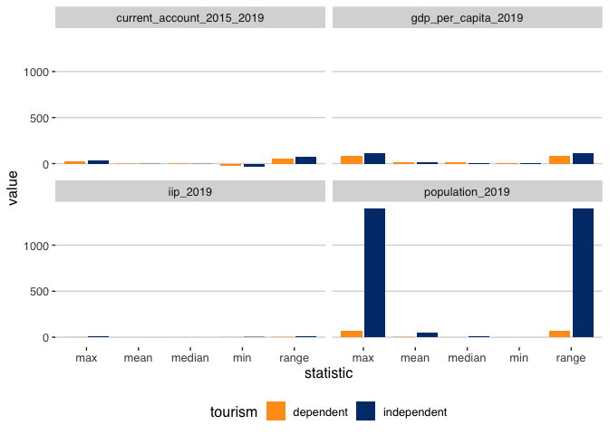

```r
tourism_dependent <-
  tourism %>%
  filter(travel_balance_2015_2019 > 5) %>%
   our_summary() %>%
  mutate(tourism = 'dependent')

tourism_independent <-
  tourism %>%
  filter(travel_balance_2015_2019 <= 5) %>%
   our_summary() %>%
  mutate(tourism = 'independent')

full_join(tourism_dependent, tourism_independent) %>%
  pivot_longer(where(is.numeric),
               names_to = 'statistic') %>%
  ggplot(aes(x = statistic, y = value, fill = tourism)) +
  geom_col(position = position_dodge2()) +
  facet_wrap(. ~ variable) +
  ggthemes::theme_hc() +
  gghutchins::scale_fill_hutchins(reverse = TRUE)
```

```r
tourism %>%
    filter(travel_balance_2015_2019 > 5) %>%
  select(gdp_per_capita_2019,
      population_2019,
      current_account_2015_2019,
      iip_2019) %>%
  skimr::skim()
```

Data summary

| Name | Piped data |
| --- | --- |
| Number of rows | 37 |
| Number of columns | 4 |
| _______________________ |  |
| Column type frequency: |  |
| numeric | 4 |
| ________________________ |  |
| Group variables | None |

**Variable type: numeric**

| skim_variable | n_missing | complete_rate | mean | sd | p0 | p25 | p50 | p75 | p100 | hist |
| --- | --- | --- | --- | --- | --- | --- | --- | --- | --- | --- |
| gdp_per_capita_2019 | 0 | 1.00 | 17262.68 | 17300.33 | 1713.31 | 5781.98 | 11771.05 | 20419.47 | 81108.87 | ▇▂▁▁▁ |
| population_2019 | 0 | 1.00 | 4.15 | 11.73 | 0.02 | 0.18 | 0.49 | 2.73 | 69.63 | ▇▁▁▁▁ |
| current_account_2015_2019 | 0 | 1.00 | -4.59 | 10.14 | -21.49 | -9.12 | -5.74 | 0.16 | 29.47 | ▃▇▃▁▁ |
| iip_2019 | 2 | 0.95 | -0.69 | 0.80 | -1.70 | -1.24 | -0.91 | -0.26 | 1.71 | ▇▅▂▂▁ |